# Silent Spring - MCF7 gene set analysis

## Silent Spring - MCF7 gene set analysis

```r
# remove all the objects
rm(list = ls())

# Set working directory
setwd("/Users/viktorian/Documents/SilentSpring/SilentSpring Data")
```

## Gene set enrichment analysis

The lists of the differentially expressed genes, for various conditions, are usually not the end point of the analysis. The second part of the analysis focus on the interpretation, where we are looking for the patterns among the differentially expressed genes. A lists of differentially expressed genes are easier to interpret if the genes exhibit similarity in their functionality. In this step analysis shifts from the level of single genes to sets of related genes, that are called pathways. Pathways are group of genes, which work together in order to process the signal and perform the certain function. Pathways are usually defined from libraries such as Gene Ontology (Ashburner et al., 2000) or KEGG (Ogata et al., 1999), which are based on previously accumulated knowledge. Definition of the pathways are always given a priori and are constructed without reference to the data.

```r
# Load the packages
library(EnrichmentBrowser)
library(biomaRt)
library(huge)
library(rags2ridges)
require(gdata)
```

```r
# Get gene IDs for gene names from ensembl
human=useMart("ENSEMBL_MART_ENSEMBL", dataset="hsapiens_gene_ensembl",host="www.ensembl.org")
ann <- getBM(attribute=c("external_gene_name", "entrezgene"), mart=human)
colnames(ann) <- c("GeneName","gene_id")
```

```r
# Remove the numbers from the gene names
genenames <- rownames(countData_matrix)
genenames <- strsplit(genenames, "_")
symbols <- integer(501)
names(symbols) <- unique(sapply(genenames, function(x) x[1]))
```

```r
# Make object that indicate differentially expressed genes
estDE <- sapply(strsplit(Estrogen_1vs0[[1]], "_"), "[", 1)
for (gene in estDE) {
  if (gene %in% names(symbols)) {
    ind <- which(names(symbols) == gene)
    symbols[ind] <- 1
  }
}
SSgen <- cbind(names(symbols),symbols)
colnames(SSgen) <- c("GeneName","diffExp")
```

```r
# Make object with all, significant and none significant genes
dat <- merge(ann,SSgen,by="GeneName")
dat[,3] <- as.numeric(as.character(dat[,3]))
sigGen <- dat[which(dat[,3]==1),]
noSigGen <- dat[which(dat[,3]==0),]
```

Now, we are interested to test whether known biological process defined within the pathway are enriched (over-represented) in the selection of the genes from our experiment, which are considered to be differentially expressed. The function generates table which indicate for all the pathways from certain repository following characteristics: pathway id, pathway name, number of the genes in the pathway, number of the genes from our experiment in the pathway, number of significant genes from our selection, p-value and adjusted p-value. Significance analysis test is performed using cross table and employing fisher exact test. Cross table compare number of non and significant genes versus number of genes in and outside the pathway. Finally, due to the high-dimensionality of the data multiplicity correction is applied on the p-values across the genes.

```r
# For illustration what actually we tested cross table of breast cancer pathway is made:
CrossTable <-
  matrix(c(24, 8, 272, 198),
         nrow = 2,
         dimnames = list(c("Diff. Expressed", "Not Diff. Expressed"),
                         c("In Breast Cancer Pathway", "Not Breast Cancer Pathway")))
CrossTable
```

```
##                     In Breast Cancer Pathway Not Breast Cancer Pathway
## Diff. Expressed                           24                       272
## Not Diff. Expressed                        8                       198
```

```r
# Function which generate pathway table
pathwayTable <- function(db, allG, sigG, noSigG){
  fin <- data.frame(matrix(ncol = 6, nrow = length(db)))
  for(i in 1:length(db)){
    fin[i,1] <- sub("_.*", "", names(db[i]))
    fin[i,2] <- gsub("_", " ", sub("^[^_]*", "", names(db[i])))
    fin[i,3] <- length(db[[i]])
    fin[i,4] <- length(intersect(as.numeric(db[[i]]),allG))
    fin[i,5] <- length(intersect(as.numeric(db[[i]]),sigG))
    CrossTab <- matrix(c(length(intersect(sigG,as.numeric(db[[i]]))),
                         length(intersect(noSigG,as.numeric(db[[i]]))),
                         length(setdiff(sigG,as.numeric(db[[i]]))),
                         length(setdiff(noSigG,as.numeric(db[[i]])))), nrow = 2,)
    fin[i,6] <- fisher.test(CrossTab, alternative = "greater")$p.value
  }
  fin$X7 <- p.adjust(fin[,6], method ="fdr")
  colnames(fin) <- c("PathwayID", "PathName", "PathSize", "OurGen",
                     "NrSigGen", "Pval","adjPval")

  return(fin[order(fin[,7], fin[,6], decreasing = F),])
}
```

For all human pathways from both KEGG and GO repository tables are generated. We can notice that GO contain significantly higher number of pathways, however KEGG pathways are better defined and biologically more relevant.

```r
# KEGG pathways
kegg.gs <- get.kegg.genesets("hsa")
resKEGG <- pathwayTable(kegg.gs, dat[,2], sigGen[,2], noSigGen[,2])
head(resKEGG)
```

```
##     PathwayID                                   PathName PathSize OurGen
## 112  hsa03440                   Homologous recombination       41     17
## 222  hsa04919          Thyroid hormone signaling pathway      116     20
## 305  hsa05224                              Breast cancer      151     32
## 92   hsa01521  EGFR tyrosine kinase inhibitor resistance       79     22
## 162  hsa04360                              Axon guidance      175      9
## 306  hsa05225                   Hepatocellular carcinoma      168     36
##     NrSigGen       Pval adjPval
## 112       14 0.03633559       1
## 222       16 0.03900427       1
## 305       24 0.04013440       1
## 92        17 0.05575762       1
## 162        8 0.06091276       1
## 306       26 0.06441818       1
```

```r
# Gene Ontology pathways
go.gs <- get.go.genesets(org="hsa", onto="BP", mode="GO.db")
resGO <- pathwayTable(go.gs, dat[,2], sigGen[,2], noSigGen[,2])
head(resGO)
```

```
##       PathwayID                         PathName PathSize OurGen NrSigGen
## 1128 GO:0006351     transcription, DNA-templated     1763     62       46
## 1103 GO:0006302       double-strand break repair       61     14       13
## 1110 GO:0006310                DNA recombination       65     14       13
## 3743 GO:0031647  regulation of protein stability       64      9        9
## 1592 GO:0007067         mitotic nuclear division      233     17       15
## 3958 GO:0032508             DNA duplex unwinding       44     13       12
##             Pval adjPval
## 1128 0.005961142       1
## 1103 0.006038680       1
## 1110 0.006038680       1
## 3743 0.008189951       1
## 1592 0.008966807       1
## 3958 0.009724551       1
```

For better overview and easier comparison of the top significant pathways, barplot and dotplot are employed. Functions allow to generate these plots.

```r
# Functioin for making bar and dot plot
pathwayBarPlot <- function(finTab){
  pathways <- rep(c(finTab[,2]),3)
  allPathGen <- finTab[,3]-finTab[,4]
  noSigGen <- finTab[,4]-finTab[,5]
  sigGen <- finTab[,5]
  values <- c(sigGen, noSigGen, allPathGen)
  type <- c(rep("Significant genes", nrow(finTab)), rep("No significant genes", nrow(finTab)),
            rep("All pathway genes", nrow(finTab)))
  mydata <-data.frame(pathways, values)
  mydata$pathways <-factor(mydata$pathways,
                           levels = c(finTab[,2]))

  p <-ggplot(mydata, aes(pathways, values))
  p +geom_bar(stat = "identity", aes(fill = type)) + coord_flip() +
  ggtitle("Dotplot of the pathways") + ylab('Number of genes') + xlab('Pathways') +
  theme(axis.text=element_text(size=12),axis.title=element_text(size=12,face="bold"),title=element_text(size=12,face="bold"))
}

pathwayDotPlot <- function(finTab){
  df <- fortify(finTab, showCategory = 10, split=split)
  df$GeneRatio <- finTab$OurGen/finTab$PathSize
  idx <- order(df$GeneRatio, decreasing = FALSE)
  df$PathName <- factor(df$PathName, levels=unique(df$PathName[idx]))
  ggplot(df, aes_string(x="GeneRatio", y="PathName",size="NrSigGen", color="Pval")) +
    geom_point() + scale_color_gradient(low="red", high="yellow") + ylab('Pathways')  +
    ggtitle("Dotplot of the pathways")+ xlab('Gene ratio (experimnet vs. pathways)') +
    theme(axis.text=element_text(size=12),axis.title=element_text(size=12,face="bold"),title=element_text(size=12,face="bold"))
}
```

In the barplot each pathway is illustrated with one bar which comprise all genes in particular pathways. Bar comprise number of differentially expressed genes, number of non-differentially expressed genes and the number of genes which are not in measured in our experiment but are in the pathway.

```r
# Make a bar plot for top pathway
```

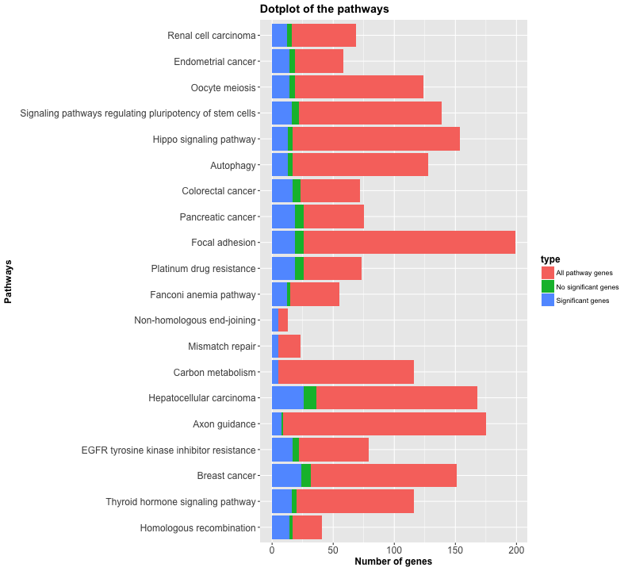

```r
pathwayBarPlot(resKEGG[1:20,])
```

On the ohter hand, dotplot represent each top significant pathway with dot. Dots are ordered based on the gene ratio between total number of genes in the pathway and number of genes measured in the experiment. Size of the plot indicate number of significant genes, while the color shows p-value of the pathway, before multiplicity correction.

```r
# Make a dot plot for top pathway
```

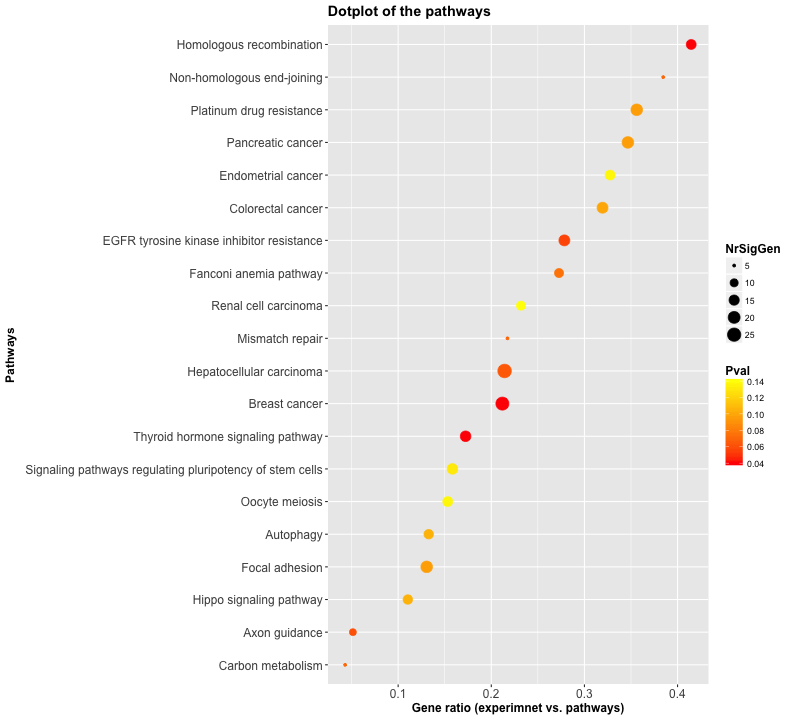

```r
pathwayDotPlot(resKEGG[1:20,])
```

## Pathway analysis - gene network reconstruction

Although we have sparse pathways representation (small number of genes measured in our experiment which represent particular pathways), we proceed with pathway analysis including genes gene counts. We are interested to reconstruct interaction among genes from breast cancer pathways using measurements of the genes from the experiment. Although we have only 32 genes from breast cancer pathways defined by KEGG, we can still investigate how they interact among each other. Especially we aim to identify genes which are regulators, due to the fact this genes are consider to be potential cancer driving genes. Methodology employed here is graphical modeling, which use ridge penalized ML estimator for precision matrix in order to identify all the interactions among the genes. Graphical modeling is based on p-dimensional Gaussian multivariate distribution, which we do not have in our data. In order to assume this distribution we previously Gaussianize our data transferring from negative binomial to normal.

```r
# Reconstruction of the interaction among the genes from Breast cancer

datax <- counts(dds)
rownames(datax) <- sapply(strsplit(rownames(datax), "_"), function(x) x[1])

datax <- aggregate(datax, list(rownames(datax)), median)
rownames(datax) <- datax[,1]
datax <- round(datax[,-1],0)

kegg.gs <- get.kegg.genesets("hsa")
PathGen <- dat[dat[,2]%in%as.numeric(kegg.gs$hsa05224),1]
brestDat <- datax[rownames(datax)%in%PathGen,]

# Gausianize data
X.npn = huge.npn(t(brestDat))
```

```
## Conducting the nonparanormal (npn) transformation via shrunkun ECDF....done.
```

```r
Cx <- covML(X.npn)

# Fit ridge penalized maximum likelihood model
ridgeEst <- ridgeP(Cx, lambda = 1, type = "Alt")

# Sparsify the precision matrix, identifying only significant gene interactions.
ridgeEst1 <- sparsify(ridgeEst, threshold = "localFDR", FDRcut = 0.9)
```

```
## Step 1... determine cutoff point
## Step 2... estimate parameters of null distribution and eta0
## Step 3... compute p-values and estimate empirical PDF/CDF
## Step 4... compute q-values and local fdr
## Step 5... prepare for plotting
```

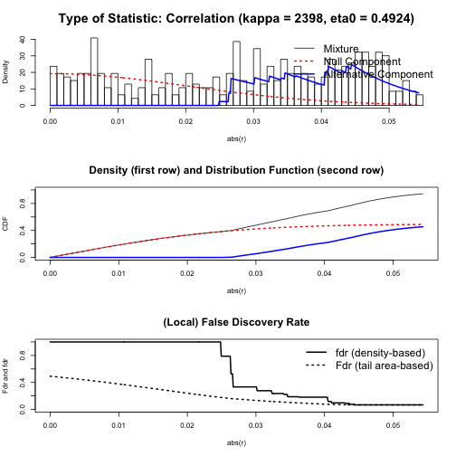

```
##
## - Retained elements:  137
## - Corresponding to 29.46 % of possible edges
##
```

```r
p <- abs(ridgeEst1[[2]])
diag(p) <- 0

# Undirected graph for visulaization of sparsified precision matrix
```

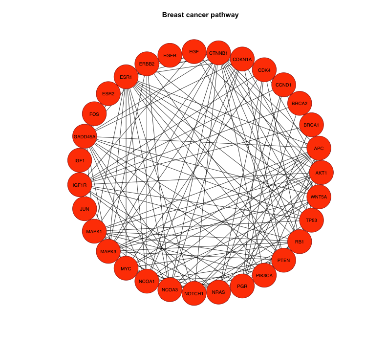

```r
Ugraph(p, type = "fancy", Vsize = 20, Vcex = 0.8, cut = 0.07, main="Breast cancer pathway")
```

Plot illustrate the network of the gene interactions where genes are represented by dots, while interactions with edges. We can notice that there are few genes which can be considered as the regulators. However, we have to keep in mind that this is rather small part of the all genes.

From the both enrichment and network reconstruction analysis, we can conclude that it is required to enlarge our selection of genes from the experiment. This will allow us to have better overview of the over-represented pathways, as well as for network reconstruction to identify genes with highest number of interactions. These genes may be considered as potential cancer driving genes and can be further investigated.